# Mahine Learning

carlos

July 28, 2017

# Overview

Here I will build a model that can predict if a user is doing the exercise very well. The data is a collection of volunters that did exercise using SmartDevices with acceletometers. The original project is in http://groupware.les.inf.puc-rio.br/har

## Get the data and look the variables

The data set is really big more than 160 colluns and almost 20 k lines. My first step was cleanning that that are not helpfull as variable that have near zero variance an a lot of NAs. Also I clean variables that are higly correlated. At the end 150 variables are throw away. The final data set consist in just 9 predictors

```r
require(caret)
fullData<-read.csv("pml-training.csv")

# check variables that will not help (near zero variance) and removing

nzv <- nearZeroVar(fullData)
filteredData<-fullData[,-nzv]


# Check NAs
Nas<-colSums(is.na(filteredData))
# exclude all variables vith NAs
filteredNoNa<-filteredData[,Nas<1]

## Correlated Variables
descr<-cov(filteredNoNa[,-c(2,5,59)])

highlyCorDescr <- findCorrelation(descr, cutoff = .75)
finalFF<-filteredNoNa[,-highlyCorDescr]
```

# Split data

I split data in training and “validating” data to mesure the performance. I call “validating” to make clear that is not the “test data” that the exercise asking for.

```r
ToTrain<-createDataPartition(finalFF$classe, p=0.6,list = F)
training<-finalFF[ToTrain,]
validating<-finalFF[-ToTrain,]
```

# Buliding the models

A built models using a repeated cross validantion procedure in 10 fold way. I build the following models 1- *rf* random florest 2- *tb* treebag, a bagged CART 3 - *cart* Classification and Regression Trees 4 - *svm* Support Vector machines

Because those models take a long time to process I use a parallel approach (this takes ~1h)

```r
fitControl <- trainControl(## 10-fold CV
                           method = "repeatedcv",
                           number = 10,
                           ## repeated ten times
                           repeats = 10
                           )

library(doMC)
registerDoMC(cores = 7)


model_rf<-train(classe~., data=training,
                method="rf",
                trControl = fitControl
               )
model_tb<-train(classe~., data=training,
                method="treebag",
                trControl = fitControl
               )

model_cart<-train(classe~., data=training,
                  method="rpart",
                  trControl = fitControl
                )

model_svm <- train(classe~., data=training,
                   method="svmRadial",
                   trControl = fitControl
                )
```

# In sample error and performance

To estimate In sample error and the performance of models I used resamples function

```r
resamps <- resamples(list(RF = model_rf,
                          tb = model_tb,
                          svm= model_svm,
                          cart= model_cart
                          ))
summary(resamps)
```

```
##
## Call:
## summary.resamples(object = resamps)
##
## Models: RF, tb, svm, cart
## Number of resamples: 100
##
## Accuracy
##           Min.   1st Qu.    Median      Mean   3rd Qu.      Max. NA's
## RF   0.9524618 0.9626089 0.9652248 0.9656251 0.9694397 0.9779287    0
## tb   0.9303314 0.9405646 0.9460954 0.9459073 0.9499151 0.9626802    0
## svm  0.6757216 0.7053704 0.7144071 0.7131284 0.7203568 0.7459643    0
## cart 0.3971088 0.4214209 0.4505728 0.4443597 0.4657477 0.4932088    0
##
## Kappa
##           Min.   1st Qu.    Median      Mean   3rd Qu.      Max. NA's
## RF   0.9398280 0.9526761 0.9560143 0.9565105 0.9613505 0.9720865    0
## tb   0.9119174 0.9248488 0.9318402 0.9315876 0.9366483 0.9528142    0
## svm  0.5866386 0.6249553 0.6363088 0.6348645 0.6443636 0.6767464    0
## cart 0.2122222 0.2441949 0.2869226 0.2778786 0.3061123 0.3406593    0
```

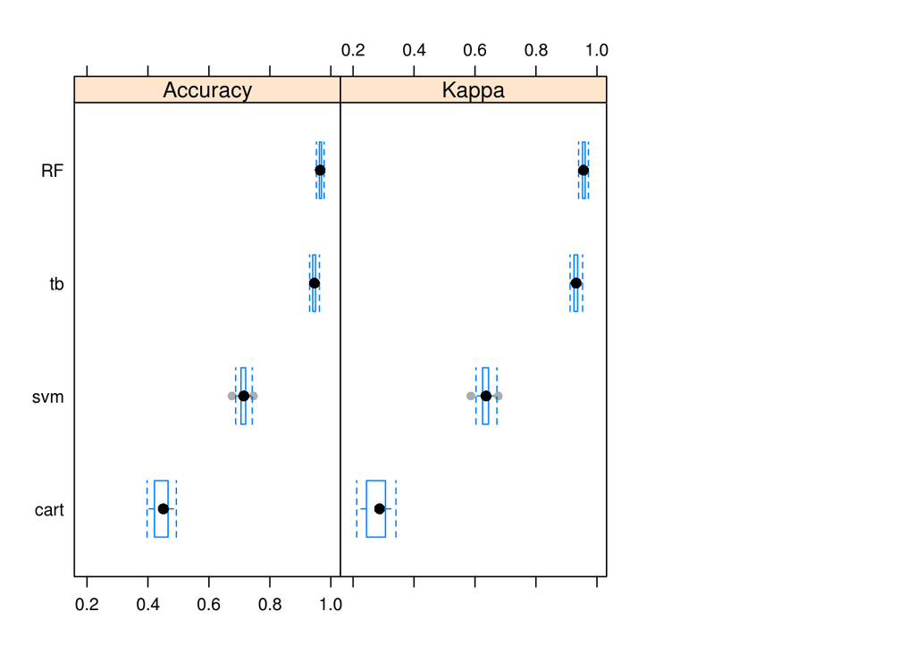

```r
theme1 <- trellis.par.get()
theme1$plot.symbol$col = rgb(.2, .2, .2, .4)
theme1$plot.symbol$pch = 16
theme1$plot.line$col = rgb(1, 0, 0, .7)
theme1$plot.line$lwd <- 2
trellis.par.set(theme1)
bwplot(resamps, layout = c(3, 1))
```

```r
preds_train = cbind(rf=predict(model_rf, training),
                    tb=predict(model_tb, training),
                    svm=predict(model_svm,training))

training2 = cbind(training, preds_train)

rf_stack = train(classe ~., data = training2, method = "rf")
```

# Validation (Out Sample error)

To validate the models and see Out sample error I use the models to predict a new dataset and check the accuracy of them

```r
prediction_rf<-predict(model_rf, validating)
prediction_tb<-predict(model_tb, validating)
prediction_svm<-predict(model_svm,validating)
prediction_cart<-predict(model_cart,validating)

prediction_rf_stack<-predict(rf_stack, cbind(validating,rf=unclass(prediction_rf),
                                             tb=unclass(prediction_tb),svm=unclass(prediction_svm)))




c_rf<-confusionMatrix(prediction_rf,validating$classe)
c_tb<-confusionMatrix(prediction_tb,validating$classe)
c_svm<-confusionMatrix(prediction_svm,validating$classe)
c_cart<-confusionMatrix(prediction_cart,validating$classe)
c_stack<-confusionMatrix(prediction_rf_stack,validating$classe)

accu<-t(data.frame(rf=c_rf$overall,
           tb=c_tb$overall,
           svm=c_svm$overall,
           cart=c_cart$overall,
           stack=c_stack$overall))
accu
```

```
##        Accuracy     Kappa AccuracyLower AccuracyUpper AccuracyNull
## rf    0.9687739 0.9604860     0.9646833     0.9725112    0.2844762
## tb    0.9457048 0.9313040     0.9404592     0.9506162    0.2844762
## svm   0.7247005 0.6497340     0.7146711     0.7345627    0.2844762
## cart  0.4124395 0.2318943     0.4015174     0.4234266    0.2844762
## stack 0.9678817 0.9593564     0.9637388     0.9716721    0.2844762
##       AccuracyPValue McnemarPValue
## rf      0.000000e+00  9.142977e-03
## tb      0.000000e+00  2.931765e-01
## svm     0.000000e+00  2.101913e-55
## cart   6.238634e-130           NaN
## stack   0.000000e+00  2.621448e-03
```

# Answer the quizz

```r
cases<-read.csv("pml-testing.csv")
predict(model_rf,cases)
```

```
##  [1] B A E A A C D B A A C C B A E E A B B B
## Levels: A B C D E
```